# GO enrichment

Ellen Dimmen Chapple

12.12.2023

```r
library(tidyverse)
library(ggplot2)
library(cowplot)
```

- NAC genes, vnd
- more functional info in arabidopsis
- use plantgenie
- relax definitions of conserved
- visualisation of conserved genes ex. vnd or something

# 1 Expression profiles

Flow: 1) Find a GO term of interest - filter the go_list to only contain genes with this term 2) Filter the ortholog group file to only contain annotated genes for the specific GO term and that only occur in the gene set we are studying (ex. ultra-conserved genes). Fill in which gene set is to be used!

```r
# GO:0009834 - plant-type secondary cell wall biogenesis
species_list <- c("Lodge", "Asp", "Nor","Scots","Birch","Cher")
conserved_genes <- read_delim("Data/DATA/textFiles/cons_genes_aspen.txt", "\t")
load("go_list.RData")

goterm_to_genes <- go_list %>%
  filter(`GO ID` == "GO:0009834") %>%
  distinct(`Sequence Name`, .keep_all = T)

ortholog_group_file <- read.delim("Data/DATA/Orthogroups.100323.tsv", header = TRUE, sep = "\t")

genes_to_all_genes <- ortholog_group_file %>%
  mutate(Pinsyl.SHORT.cp.pep = Pinsyl.SHORT.pep) %>%
    rename(
    Asp = Poptre.SHORT.pep,
    Birch = Betpen.SHORT.pep,
    Nor = Picabi.SHORT.pep,
    Scots = Pinsyl.SHORT.pep,
    Cher = Prunavi.SHORT.pep,
    Lodge = Pinsyl.SHORT.cp.pep,
    OrthoGroup = Orthogroup) %>%
  separate_rows(Asp, sep = ", ") %>%
  mutate(Asp = gsub("Poptre_", "", Asp)) %>%
  mutate(Asp = gsub("\\.\\d\\.p\\d$", "", Asp)) %>%
  filter(Asp %in% goterm_to_genes$`Sequence Name`) %>%
  filter(Asp %in% conserved_genes$Asp) %>%
  select(OrthoGroup, species_list) %>%
  distinct(Asp, .keep_all = T)
```

2. If there are multiple genes for a GO term (in Aspen), compare the genes by studying both their expression profiles and all other associated GO terms.

```r
file_list_2 <- c()
for (i in species_list){

  expr_name <- paste0("Data/DATA/transcriptomicsData/",i,"Wood_transcriptomics.txt")
  file_list_2 <- append(file_list_2, expr_name, after = length(file_list_2))

}

# Filter genes to only contain the genes associated with the GO-term.
expression_vector_asp <- read_delim(file_list_2[2]) %>%
  filter(Genes %in% genes_to_all_genes$Asp) %>%
  select(Genes, contains("1.")) %>%
  t()
```

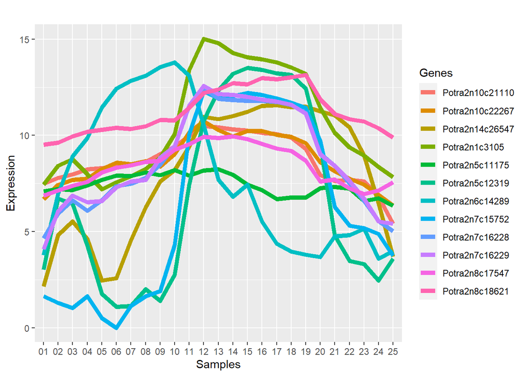

```r
colnames(expression_vector_asp) <- expression_vector_asp[1,]
expression_vector_asp <- expression_vector_asp[-1,] %>%
  as.data.frame() %>%
  rownames_to_column(var = "Samples")

longer_expr <- expression_vector_asp %>%
  pivot_longer(c(-1),names_to = "Genes", values_to = "Expression") %>%
  mutate_at("Expression", as.numeric) %>%
  mutate(Samples = gsub("A1.", "", Samples)) %>%
  group_by(Genes)



plot_asp <- ggplot(data = longer_expr, aes(x = Samples, y = Expression, col = Genes, group = Genes)) +
      geom_line(linewidth = 2) +
      ggtitle("") + ylab("Expression")

plot_asp
```

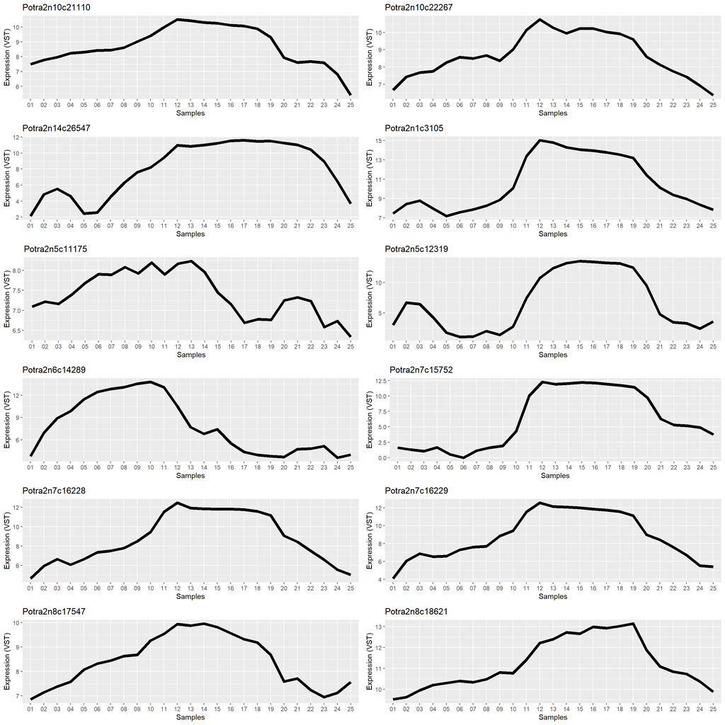

```r
# Does the same as above, but gives a separate plot for each gene.

genes_to_plot <- c(unique(longer_expr$Genes))
plots <- list()

for(i in 1:length(genes_to_plot)){
  gene <- genes_to_plot[i]
  df <- longer_expr %>%
    filter(Genes == gene)

  plots[[length(plots)+1]]  <- ggplot(data = df, aes(x = Samples, y = Expression, group = Genes)) +
    geom_line(linewidth = 2) +
    ggtitle(gene) + ylab("Expression (VST)")



}

plot_grid(plotlist = plots, ncol = 2)
```

**Comments**

Most genes share a similar curve where there is a peak around sample 12. These genes are not orthologs, but all share one GO. Before choosing one of these (and then going with this ortholog group), take a look at each gene in PlantGenie to see what other GOs the gene has.

According to PlantGenie, the following genes actually contain the GO:

“Potra2n14c26547” “Potra2n5c11175”  
“Potra2n5c12319”  
“Potra2n7c15752” **

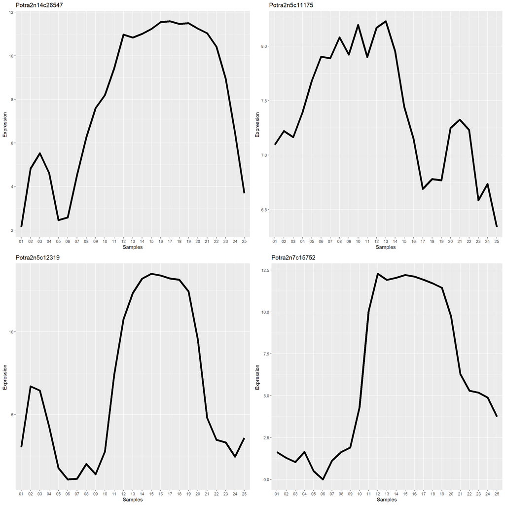

```r
genes_to_plot_filtered <- c( "Potra2n14c26547",  "Potra2n5c11175",  "Potra2n5c12319" ,  "Potra2n7c15752")
plots <- list()

for(i in 1:length(genes_to_plot_filtered)){
  gene <- genes_to_plot_filtered[i]
  df <- longer_expr %>%
    filter(Genes == gene)

  plots[[length(plots)+1]]  <- ggplot(data = df, aes(x = Samples, y = Expression, group = Genes)) +
    geom_line(linewidth = 2) +
    ggtitle(gene) + ylab("Expression ")



}

plot_grid(plotlist = plots, ncol = 2)
```

```r
aspGene_to_OG <- genes_to_all_genes %>%
  filter(Asp == "Potra2n5c12319")


OG_to_genes <- aspGene_to_OG %>%
  separate_rows(Birch, sep = ", ") %>%
  separate_rows(Cher, sep = ", ") %>%
  separate_rows(Nor, sep = ", ") %>%
  separate_rows(Lodge, sep = ", ") %>%
  separate_rows(Scots, sep = ", ")



for(i in 2:ncol(OG_to_genes)){
  col <- colnames(OG_to_genes[i])

  cat("Species: ", col, "\n")
  cat("Number of unique genes: ",nrow(unique(OG_to_genes[,i])), "\n")
  cat("Genes: ", "\n")
  print(unique(OG_to_genes[i]))
  cat("\n")
  cat("\n")
}
```

```
## Species:  Lodge
## Number of unique genes:  2
## Genes:
## # A tibble: 2 × 1
##   Lodge
##   <chr>
## 1 Pinsyl_asmbl_118003.p1.p1
## 2 Pinsyl_asmbl_136374.p1.p1
##
##
## Species:  Asp
## Number of unique genes:  1
## Genes:
## # A tibble: 1 × 1
##   Asp
##   <chr>
## 1 Potra2n5c12319
##
##
## Species:  Nor
## Number of unique genes:  2
## Genes:
## # A tibble: 2 × 1
##   Nor
##   <chr>
## 1 PICAB_chr01_M00000128443.p1
## 2 PICAB_sUL08_M00001771199.p1
##
##
## Species:  Scots
## Number of unique genes:  2
## Genes:
## # A tibble: 2 × 1
##   Scots
##   <chr>
## 1 Pinsyl_asmbl_118003.p1.p1
## 2 Pinsyl_asmbl_136374.p1.p1
##
##
## Species:  Birch
## Number of unique genes:  3
## Genes:
## # A tibble: 3 × 1
##   Birch
##   <chr>
## 1 Betpen_Bpev01.c0088.g0120.m0001
## 2 Betpen_Bpev01.c1418.g0002.m0001
## 3 Betpen_Bpev01.c2001.g0008.m0001
##
##
## Species:  Cher
## Number of unique genes:  3
## Genes:
## # A tibble: 3 × 1
##   Cher
##   <chr>
## 1 Prunavi_FUN_005992-T1.p1
## 2 Prunavi_FUN_027493-T1.p1
## 3 Prunavi_FUN_027494-T1.p1
```

For the selected Aspen-gene there are 2-3 orthologs within the other species.

2. Find the orthologs to this gene. OBS! There will be multiple orthologs, so plot them all

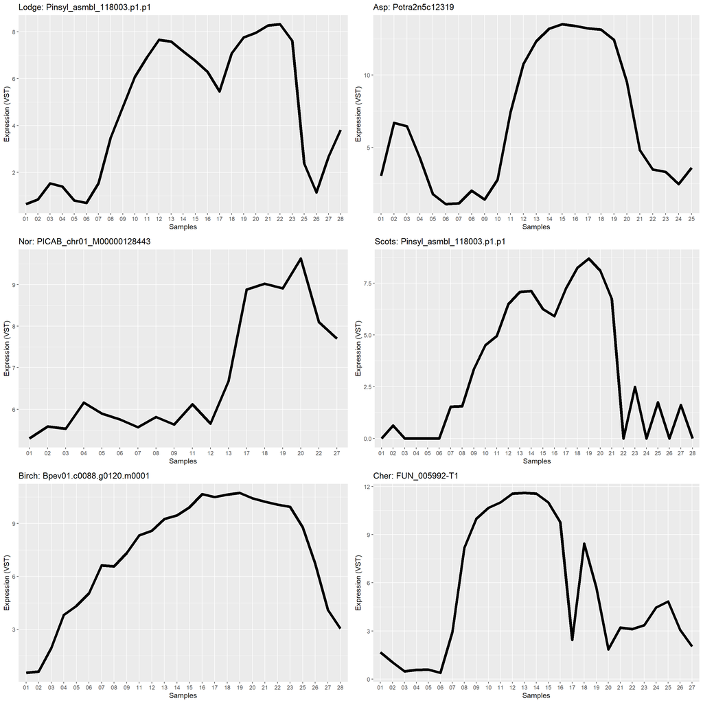

```r
genes_to_plot_all <- OG_to_genes %>%
  mutate(Birch = gsub("Betpen_", "", Birch)) %>%
  mutate(Cher = gsub("Prunavi_", "", Cher)) %>%
  mutate(Nor = gsub("\\.p\\d$", "", Nor)) %>%
  mutate(Cher = gsub("\\.p\\d$", "", Cher)) %>%
  slice(1)


expression_all_longer <- data.frame()


for(i in 1:length(file_list_2)){

  species <- colnames(genes_to_plot_all[i+1])
  ortholog <- c(as.character(genes_to_plot_all[1, i+1]))


  expression_vector <- read_delim(file_list_2[i])  %>%
    select(Genes, contains("1."))

  samples <- colnames(expression_vector)[-1]

  expression_vector_t <- t(expression_vector)

  colnames(expression_vector_t) <- expression_vector_t[1,]
  expression_vector_t <- expression_vector_t[-1,] %>%
    as.data.frame() %>%
    mutate(Samples = samples) %>%
    select(Samples, ortholog)


  longer <- expression_vector_t%>%
    pivot_longer(c(-1),names_to = "Genes", values_to = "Expression") %>%
    mutate_at("Expression", as.numeric) %>%
    mutate(Samples = gsub("^(.+?).", "", Samples)) %>%
    mutate(Species = rep(species, length(samples)))



  expression_all_longer <- rbind(expression_all_longer,longer)


}
expression_all_longer <- expression_all_longer %>%
  group_by(Genes)

plots <- list()
for(i in 1:length(unique(expression_all_longer$Species))){

  species <- unique(expression_all_longer$Species)[i]


  df <- expression_all_longer %>%
    filter(Species == species)

  gene <- unique(df$Genes)

  sub_title <- paste0(species, ": ", gene)

  plots[[length(plots)+1]]  <- ggplot(data = df, aes(x = Samples, y = Expression, group = Genes)) +
    geom_line(linewidth = 2) +
    ggtitle(sub_title) + ylab("Expression (VST)")



}


plot_grid(plotlist = plots, ncol = 2)
```